# Presentation for Parent Child Height Modeling and Prediction Application

April 22, 2022

## Background

This application is for modeling and prediction of child’s height using Parents’ Data. It is made interactive using Shiny. The model is created using the tabulated data set that Galton used in 1885 to study the relationship between a parent’s height and their children.

In the data set, there are 928 observations that contain 205 different parents and 928 children with the following 2 variables:  
- Child: The child’s height  
- Parent: The “midparent’s” height

The midparent’s height is an average of the father’s height and 1.08 times the mother’s.

## Galton Data

The following shows the graphical representation of the Galton data:

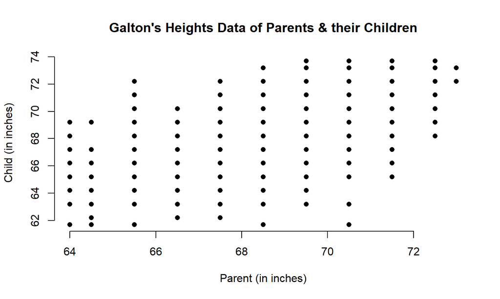

## Prediction Model

Using the Galton Data, a linear regression model is used to predict child’s height using parents’ height. The following r code will generate the model:

```r
  model <- lm(child ~ parent, data = galton)
  intercept <- model$coefficients[1]
  slope <- model$coefficients[2]
```

The resulting intercept is 23.9415302 with slope 0.6462906.

## Predicting Child’s Height

In this web application, the user could slide the bar to select the “midparent’s” height. The resulting prediction of the child’s height will then be displayed on the main panel.

For example, if no selection is made, the default midparent’s height is 65 inches. The following r code will predict the child’s height:

```r
  childheight <- intercept + slope * 65
```

The resulting height of the child is 65.950418 inches. By varying the midparent’s height via sliding the bar, it will result in different child’s height.

In addition, the users could also click the checkbox on the side panel to display the linear model line on the graph.